# MACS205 : TD3

*2/* On a
$$I_{2M} - I_M = E_{2M} - E_M \simeq \frac{1}{16} E_M - E_M = -\frac{15}{16} E_M = - 15 \cdot E_{2M}$$
d’où
$$E_{2M} \simeq \frac{I_M - I_{2M}}{15}\ .$$

```r
evalErrSimpson = function(FUN,a,b,M){
  ## Computes an approximation E of the error
  ## for the composite Simpson rule of step h=(b-a)/(2M).
  ##This requires computing I_M and I_{2M}.
  ##The value  q = I_{2M} is also returned.
  qth = trapezeInt(FUN,a,b,M)   ## M +1 evaluations
  qth2 = refineTrapeze ( FUN,a,b,M,qth )  ## M evaluations
  qth4 = refineTrapeze ( FUN,a,b,2*M,qth2 )   ## 2M evaluations
  simps_h  = 4/3*(qth2 - 1/4* qth)
  simps_h2 = 4/3*(qth4 - 1/4* qth2)
  q = simps_h2
  E = (simps_h - simps_h2)/15
  return(c(E,q))
}
```

*3/* Test de l’évaluation de l’erreur :

```r
d = 13.4 ; M=9
a = 0.5; b=3;
pol = function(x){x^d}
trueInt = (b^(d+1) - a^(d+1))/(d+1)
vv= evalErrSimpson(pol,a,b, M)
q = vv[2] ; E = vv[1]
estErr = E
trueErr = q - trueInt
relativeErrorOnError = (trueErr - estErr)/trueErr
relativeErrorOnError
```

```
## [1] 0.01973201
```

**Exercice 6**

*1/*

On a $p_{m,k}(x) = L_{k - m}^{x_=mM,\ldots,x_k} A(x)$. Or on remarque par des calculs immédiat que $\frac{(x - x_m) p_{m + 1,k}(x) - (x - x_k) p_{m,k - 1}(x)}{x_k - x_m}$ coïncide avec $p_{m,k}(x)$ sur tous les $x_m,\ldots,x_k$, soit en $k + 1$ points disctincts. Puisqu’ils sont de degré $k$ on en déduit l’égalité voulue.

*2/* D’après le résultat précédent il vient : \begin{align*} q_{m,k} & = \frac{-x_m q_{m + 1,k} + x_k q_{m,k - 1}}{x_k - x_m} \\ & = \frac{q_{m + 1,k} - \frac{x_k}{x_m} q_{m,k - 1}}{1 - \frac{x_k}{x_m}} \\ & = \frac{q_{m + 1,k} - \delta^{k - m} q_{m,k - 1}}{1 - \delta^{k - m}} \end{align*}

*3/* En posant $i = k$ et $j = i - m$ on déduit directement du résultat précédent :
$$A_{i,j} = q_{i - j,i} = \frac{q_{i - j + 1,i} - \delta^{j} q_{i - j,i - 1}}{1 - \delta^j} = \frac{A_{i,j - 1} - \delta^{j} A_{i - 1,j - 1}}{1 - \delta^j}\ .$$

```r
richardson = function(FUN,n,t,delta){
  ## Calcule le tableau des differences  divisees en 0 du
  ## polynome d'interpolation en t,delta t, ... delta^n t
  ## renvoie un vecteur de taille n+1:
  ## le vecteur des A_{k,k}, k= 0 .. n
  ## (pas la matrice).
  ## La meilleure approximation est le dernier element A[n+1].
  ##
  lx = log(t)  +  log(delta) *(0:n)
  x = exp(lx)
  A = sapply(x,FUN)
  for( j in 2:(n+1)){
    A[j : (n+1)] = (A[j : (n+1)] - delta^j * A[(j-1) : n]) / (1 - delta^j)
  }
  return(A)
}
```

Test :

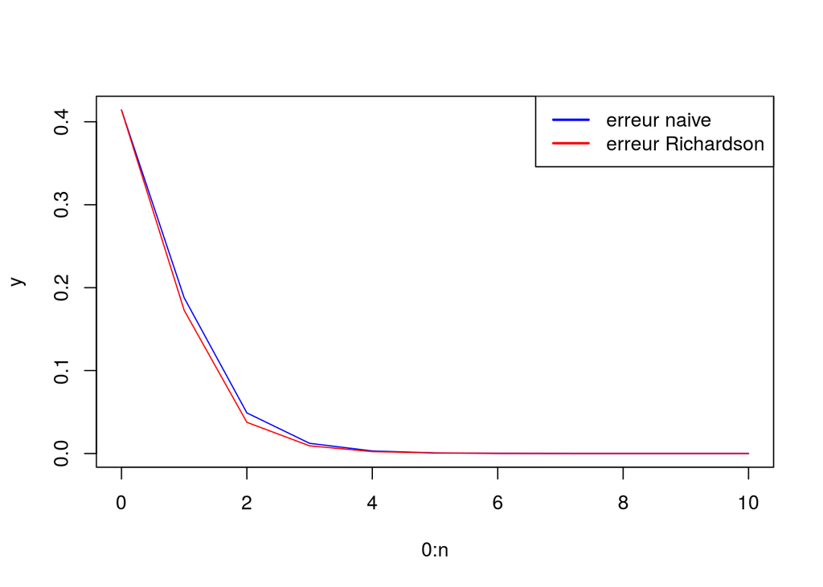

```r
myfun = function(x){sin(x)+ (cos(x)-1)*sin(2*x)}
n =10 ; t =pi/4 ;  delta = 1/4
A = richardson(myfun,n,t,delta)
lx = log(t) +  log(delta)*(0:n)
x = exp(lx);
y = sapply(x,myfun);

plot(0:n, y,col='blue', type = "l")
lines( 0:n,A,col='red');
legend('topright', legend=c('erreur naive', 'erreur Richardson'),
       col=c('blue', 'red'), lwd=2)
```

```r
dev.new()
LerrRich = log(abs(A - myfun(0))) ;
LerrNaive = log(abs(y - myfun(0)));
plot(-lx, LerrNaive,col='blue',type='l')
lines(-lx, LerrRich,col='red')
grid()
legend('topright', legend=c('log-erreur naive','log-erreur Richardson'),
       col=c('blue', 'red'), lwd=2)
```

[output not shown]

**Exercice 7**

```r
romberg = function(FUN,n,a,b,M){
    ## methode de Romberg avec n etapes
    ## appliquee sur la fonction FUN sur l'intervalle (a,b), avec un
    ## pas initial h = (b-a)/M
    h= (b-a)/M
    A = rep(0, n+1)
    A[1] = trapezeInt(FUN,a,b,M);
    Mc = M
    ## initialisation des differences divisees
    for( i in 2:(n+1) ){
        A[i] = refineTrapeze(FUN, a, b, Mc, q = A[i-1])
        Mc = 2*Mc
    }
    delta = 1/4;
    for (j in 2:(n+1)){
        A[j : (n+1)] = (A[j : (n+1)] - delta^j * A[(j-1) : n]) / (1 - delta^j)
    }
    return(A)
}
```

*2/*

```r
myfun = function(x) { cos(x) }
n = 1; M = 3; a = 0; b = pi/2
I1 = romberg(myfun, n, a, b, M)
I2 = simpsonInt(myfun, a, b, M)
diff = I1[n + 1] - I2
diff
```

```
## [1] -0.08601626
```

*3/* Test :

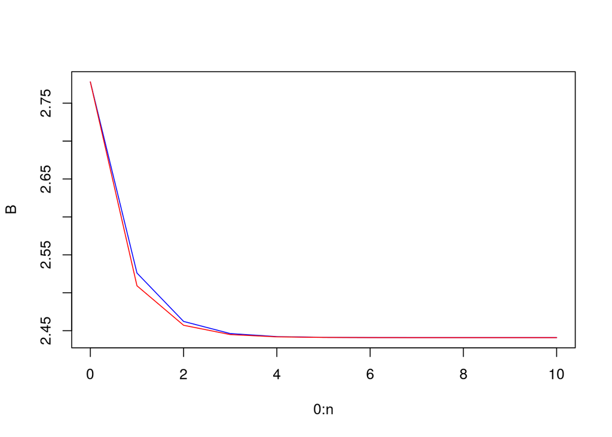

```r
d=6
myfun = function(x){x^d}
n =10; M = 5; a= 0 ; b = 1.5
A = romberg(myfun, n, a, b , M)
B = rep(0,n+1)
B[1] = trapezeInt(myfun,a,b,M)
Mc = M
for( i in  2:(n+1)){
    B[i] = refineTrapeze( myfun,a,b, Mc, B[i-1])
    Mc = 2* Mc
}

plot(0:n, B,col='blue', type='l')
lines( 0:n, A,col = 'red');
```

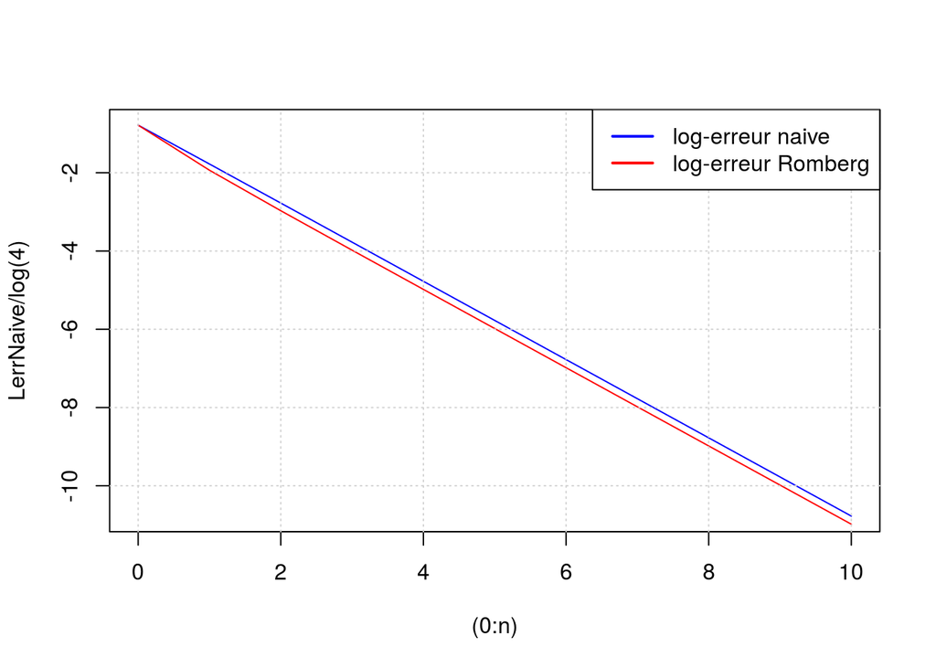

```r
LerrRich = log(abs(A - (b^(d+1) - a^(d+1))/(d+1))) ;
LerrNaive = log(abs(B - (b^(d+1) - a^(d+1))/(d+1)));
plot((0:n), LerrNaive/log(4),col='blue',type='l')
lines( (0:n), LerrRich/log(4), col='red')
grid()
legend('topright', legend=c('log-erreur naive', 'log-erreur Romberg'),
       col=c('blue', 'red'), lwd=2)
```